# 102L1 slides

## 102 Seminar

### Introduction to Python and Jupyter notebook.

#### Vivek Yadav, PhD

### Overview

- Python introduction and installations
- Introduction to jupyter notebook interface
- Resources, stackoverflow, pythonprogramming.net
- Introduction to numpy, matplotlib, pandas and sklearn
- First program

## Python

Official webpage, https://www.python.org/

### Why python?

1. Easy to learn.
2. Easy web programming, via Django, Pyramid or Flask.
3. Easy desktop development via Pygame (game development), wxPython
4. Highly scalable and transferrable.
   - Good integration with C/C++
   - Easy to transition from Python to high-level web development platforms, Javascript or Ruby
   - Functional/Recursive programming easy extension to other programming frameworks.
   - Py interface to almost all programming environments.
5. Strong community support

### Python variable types

- Numbers (constants or scalars)
- Arrays (vector or matrices of scalars)
- String (characters or sentences)
- List (lists are collections of variables of different types)
- Tuple
- Dictionary

### Python variable scoping

- Python uses static scoping of variables
- Each variable is defined once, and is accessible to all the functions and subroutines below the program where the variable is first defined. As against MATLAB that uses dynamic scoping where each variable is defined and is accessible only within a function.
- Effective memory management, makes programs faster.
- Need to be careful, a code with errors may run without any warning

### Good resources

1. https://trinket.io/python
2. Perhaps the best collection of Python lessons with code https://www.youtube.com/user/sentdex/playlists
3. Friendly introduction to complex concepts with code. https://www.youtube.com/channel/UCWN3xxRkmTPmbKwht9FuE5A

## Installations

- Easiest way to install python is via anaconda environment.
- Choose anaconda3 (python 3.5 version). https://www.continuum.io/downloads
- Download and install anaconda 3
- Launch jupyter notebook using,

```
jupyter notebook
```

[figure not shown]

Write code and press shift+enter to run the program.

[figure not shown]

### Four packages

1. numpy: Package for numerical calculations
2. matplotlib: Package for plotting
3. pandas: Package for handling tabular data
4. sklearn: Machine learning package

### Anatomy of a python program

1. Load or Generate data
2. Perform initial data exploration
3. Choose appropriate model
4. Apply model and test predictions

```python
# Importing packages
import numpy as np
import matplotlib.pyplot as plt
%matplotlib inline
```

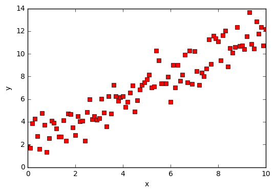

```python
# Generate synthetic data
x = np.linspace(0,10,101) # Generate 101 points between 0 and 10, every .1
y = x + 2+np.random.randn(len(x)) # Generate y = x + random_values

# Plot x vs y
plt.plot(x,y,'rs')
plt.xlabel('x')
plt.ylabel('y')
```

```python
### Getting 1st element of x

x_first = x[0] # Note indices start from 0 and go until end
# Square brackets are used to access elements of the matrix, vs curved brackets in MATLAB.

print('First value is ' + str(x_first))
```

```
First value is 0.0
```

```python
### Number of data points

x_length = len(x) # Note indices start from 0 and go until end

print('Number of data points in the data set is ' + str(x_length))
```

```
Number of data points in the data set is 101
```

### Fit line between x and y

$$ y = mx + c + error $$

Must be stasfied as closely as possible by all points, i.e. minimize error

### Errors

Error of first point:

$$ y_1 = mx_1 + c + error_1 $$

Error of second point:

$$ y_2 = mx_2 + c + error_2 $$

Error of \( i \) point:

$$ y_i = mx_i + c + error_i $$

### Optimization

Goal is to find \(m\) and \(c\) to minimize,

$$ Total~error = error_1^2 + error_2^2 + \dots + error_N^2 $$

Why sum of square?

Rewrite error equations

$$ y = mx + c + error $$

as

$$ \left[ \begin{array}{c} y_1 \\ y_2 \\ \vdots \\ y_N \end{array} \right] = \left[ \begin{array}{c} x_1 & 1 \\ x_2 & 1 \\ \vdots \\ x_N & 1 \end{array} \right] \left[ \begin{array}{c} m \\ c \end{array} \right] + \left[ \begin{array}{c} error_1 \\ error_2 \\ \vdots \\ error \end{array} \right] $$

#### Once we have data in this form, we can compute m and c to minimize sum square of errors.

### Find the best-fit between x and y

Easiest way to find the best line is to use sklearn's regression package.

1. Google 'sklearn regression'
2. Look at an example of regression
3. Use the example and fit to data

[figure not shown]

##### From sklearn documentation, need to express vector 'x' in appropriate form.

- For loop. For loop runs for a certained predefined number of iterations

```python
XX = [] # Make a blank list
for i in range(len(x)):
    x_i = [x[i]] # Make a list with
    XX.append(x_i)
XX = np.array(XX)

print(XX[:4]) # First 4 entries of XX
print(y[:4]) # First 4 entries of XX
```

```
[[ 0. ]
 [ 0.1]
 [ 0.2]
 [ 0.3]]
[ 1.84513864  1.69700725  3.83890222  4.25975876]
```

```python
from sklearn import linear_model
reg = linear_model.LinearRegression()
reg.fit(XX,y)
```

```
LinearRegression(copy_X=True, fit_intercept=True, n_jobs=1, normalize=False)
```

```python
## Predict using line fit
y_pred = reg.predict(XX)
y_pred2 = reg.coef_[0]*x+reg.intercept_
```

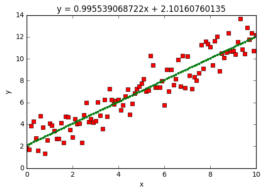

```python
# Plot x vs y
plt.plot(x,y,'rs')
plt.plot(x,y_pred,'b')
plt.plot(x,y_pred2,'g.')

plt.xlabel('x')
plt.ylabel('y')
plt.title('y = ' + str(reg.coef_[0]) + 'x + ' + str(reg.intercept_) )
```

To do

1. Use for loop to calculate square of error.
2. Choose different values of slope and intercept, compute error and verify that the error is larger than the minimum error